# Aptitude_test

1. Question 1: A car travels 180 miles in 3 hours, during which it encounters a traffic slowdown reducing its speed by 20%. What is its average speed during the slowdown?

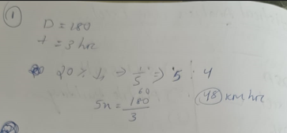

1. Question 2: A train travels from City A to City B at an average speed of 75 km/h and returns at an average speed of 60 km/h. If the total travel time is 8 hours, what is the one-way distance between the cities?

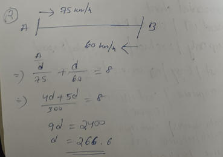

1. Question 3: A cyclist starts at point P and travels at a speed of 15 km/h for 2 hours, then increases the speed to 20 km/h for the next 1.5 hours. What is the total distance covered?

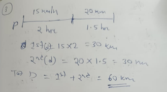

1. Question 4: A boat travels upstream for 4 hours at a speed of 12 knots and downstream for 3 hours at a speed of 18 knots. What is the speed of the stream?

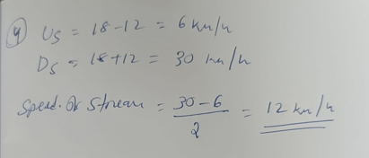

1. Question 5: If a person walks at a certain speed for 2 hours and covers a distance of 30 km, how much time will it take to cover the same distance at 25% faster speed?

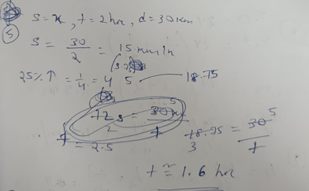

1. Question 6: A car travels for the first hour at 40 mph, the next two hours at 60 mph, and the final hour at 30 mph. What is the average speed for the entire journey?
1. Question 7: If a train travels at a speed of 90 km/h for half the journey and 120 km/h for the remaining half, what is its average speed for the entire journey?

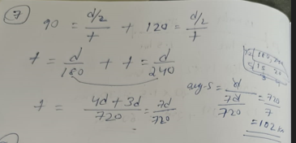

1. Question 8: A runner covers a distance of 24 miles. If he runs half of the distance at 8 mph and the remaining half at 12 mph, what is his average speed for the entire run?

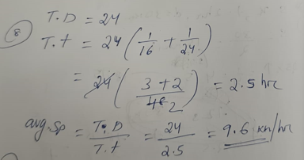

1. Question 9: A car covers the first 100 miles at a speed of 50 mph and the next 100 miles at 75 mph. What is the average speed for the entire journey?

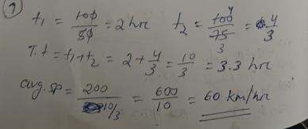

1. Question 10: A cyclist starts at point A and travels at a speed of 18 km/h for 1.5 hours, then decreases the speed to 12 km/h for the next 2 hours. What is the total distance covered?

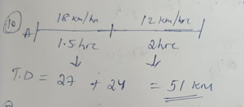

1. Question 11: A boat covers a distance of 150 miles downstream in 5 hours and the same distance upstream in 7.5 hours. Calculate the speed of the boat and the speed of the stream.

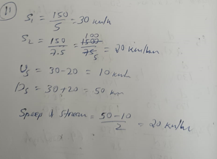

1. Question 12: If a car travels at an average speed of 55 mph for the first half of the journey and 65 mph for the second half, what is the average speed for the entire journey?

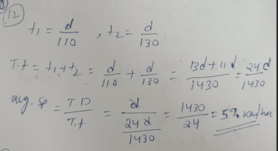

1. Question 13: A train covers the first 120 km at a speed of 80 km/h and the next 80 km at 100 km/h. Calculate the average speed for the entire journey.

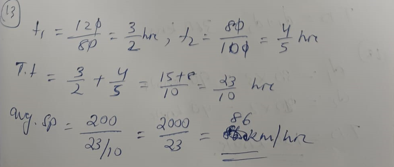

1. Question 14: A plane flies at a speed of 500 mph for the first 2 hours, then decreases its speed to 400 mph for the next 1.5 hours. What is the total distance covered?

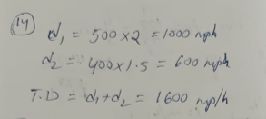

1. Question 15: If a cyclist covers a certain distance at a speed of 25 km/h, how much faster should he travel to reduce the time taken by 20%?
1. Question 16: A car covers the first 60 miles at a speed of 45 mph and the next 60 miles at 30 mph. Calculate the average speed for the entire journey.

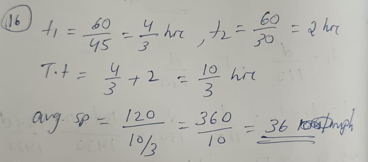

1. Question 17: A train travels at a speed of 120 km/h for 2 hours, then reduces its speed to 80 km/h for the next 1.5 hours. What is the total distance covered?

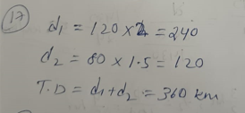

1. Question 18: If a boat travels at a speed of 30 knots for the first 3 hours and 20 knots for the next 2 hours, what is the total distance covered?

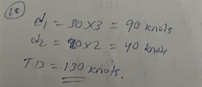

1. Question 19: A car travels for the first 2 hours at a speed of 60 mph and the next 3 hours at 45 mph. What is the average speed for the entire journey?

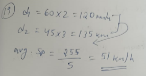

1. Question 20: If a cyclist travels at a speed of 15 km/h for 2 hours and 20 km/h for the next 1.5 hours, what is the total distance covered?

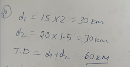

1. Question 21: A train covers the first 150 km at a speed of 100 km/h and the next 50 km at 75 km/h. Calculate the average speed for the entire journey.

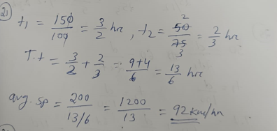

1. Question 22: A car covers the first 80 miles at a speed of 70 mph and the next 80 miles at 90 mph. What is the average speed for the entire journey?

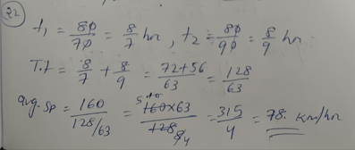

1. Question 23: If a boat travels upstream for 3 hours at a speed of 15 knots and downstream for 2 hours at a speed of 25 knots, what is the speed of the stream?

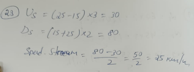

1. Question 24: A runner covers the first 10 miles at a speed of 8 mph and the next 10 miles at 12 mph. What is the average speed for the entire run?

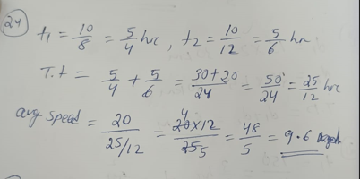

1. Question 25: If a car travels at an average speed of 50 mph for the first half of the journey and 60 mph for the second half, what is the average speed for the entire journey?

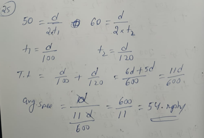

1. Question 26: A cyclist travels at a speed of 20 km/h for 2 hours and then increases the speed to 30 km/h for the next 1.5 hours. What is the total distance covered?

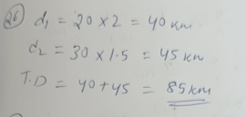

1. Question 27: A boat covers a distance of 120 miles downstream in 4 hours and the same distance upstream in 6 hours. Calculate the speed of the boat and the speed of the stream.

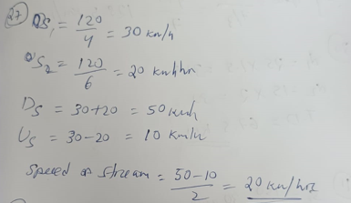

1. Question 28: If a car travels at an average speed of 65 mph for the first half of the journey and 75 mph for the second half, what is the average speed for the entire journey?

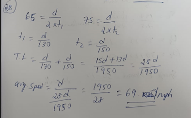

1. Question 29: A train covers the first 200 km at a speed of 120 km/h and the next 100 km at 150 km/h. Calculate the average speed for the entire journey.

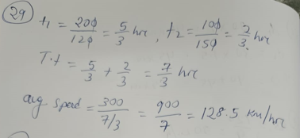

1. Question 30: If a cyclist travels at a speed of 25 km/h for 1.5 hours and then decreases the speed to 15 km/h for the next 2 hours, what is the total distance covered?

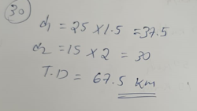